# Aqua-Coloured Toyota Aquas!

## What was my inspiration?

Every time I go out in my blue Toyota Aqua, I find myself encountering so many others with the exact same car and colour! I decided to log data about the number of Toyota Aquas I saw when I went out in my car, recording things such as the time and duration of my trip, alongside what colours I saw.

Below is a photo of my car and one of its many clones.

[figure not shown]

My car

## Rate of Aquas and Time of Day

My first question was - I’m seeing so many Toyota Aquas, but I’m wondering if this changes depending on the time of day I go out? I converted my timestamps from Google Form submission from a character vector to a time format in R, and made the y-axis by dividing the number of Aquas I saw by the number of minutes I was out. I then decided to track the two numeric variables with a dot plot with a line graph, with each dot being a trip in my car.

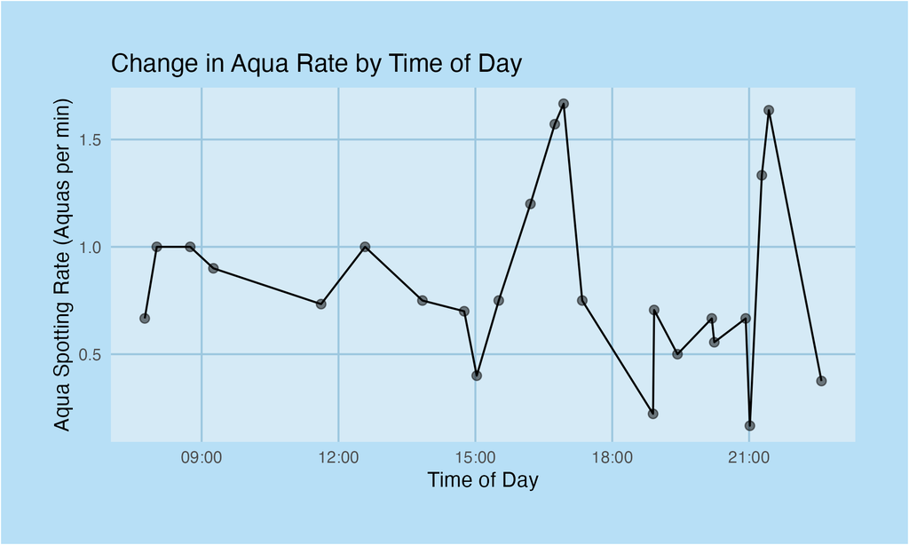

Change in Aqua Rate by Time of Day

## Proportion of Blue Aquas

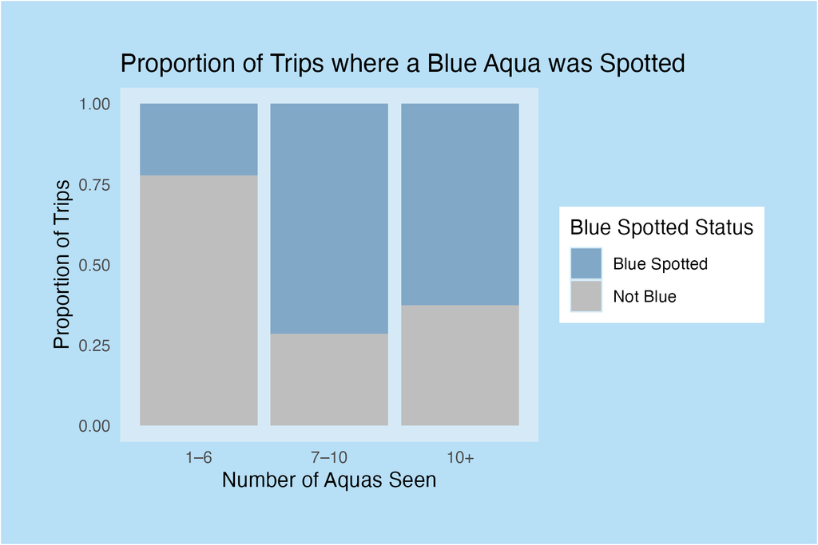

Proportion of Blue Aquas Spotted by Number of Aquas

As expected, the chance of seeing a Toyota Aqua increased between the 1-6 Aqua and 7-10 Aqua groups. Interestingly, the 10+ group has a slightly smaller proportion than the 7-10 group. This is likely due to error, which is unsurprising given the small sample size.

## Trying out cutting shapes!

I decided to have fun and see how this would look as a regular barplot, while also using the cuttingshapes package to make the bars filled with a very zoomed in image of my car, giving an interesting colour gradient!

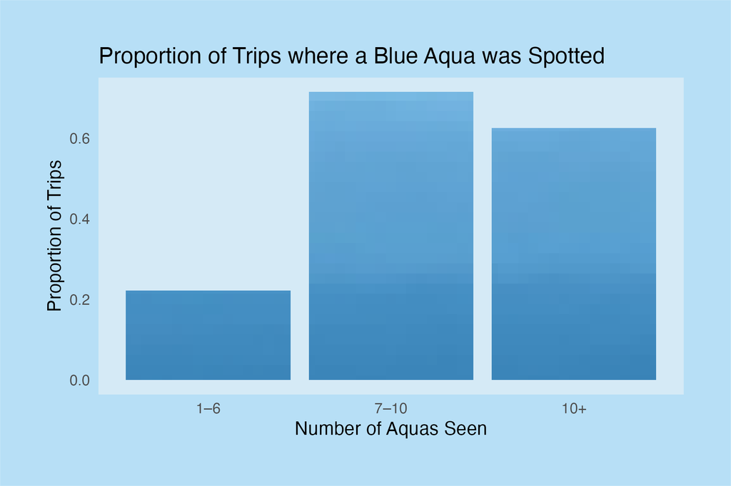

## Trip Duration and Blue Aquas

I was very surprised that the proportion of trips with over 10 Aquas spotted only had a proportion of less than 70% of blue Aquas being seen, despite me noticing so many blue Aquas while driving! I decided to make a boxplot to see if mean length of trips where a blue Aqua was spotted were longer than those where none were seen. I felt like I was seeing many Aquas even on short trips, so this is a way of checking if I was biased!

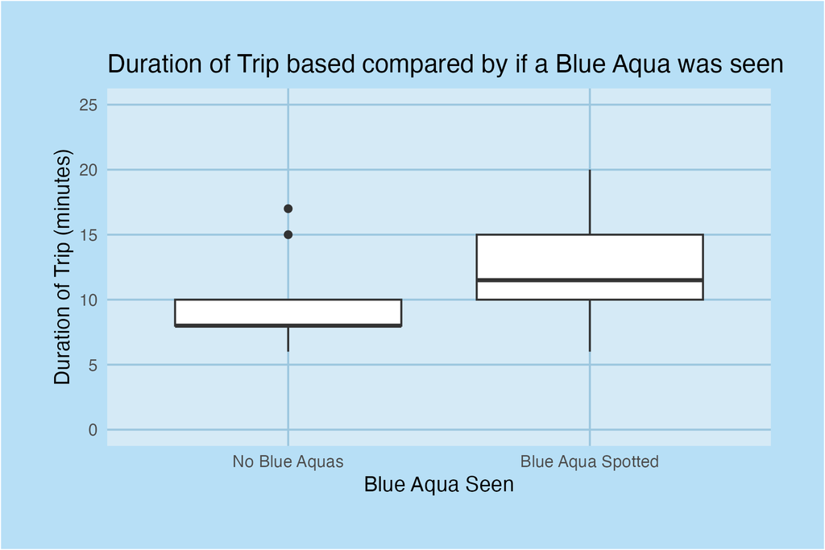

Duration of Trip based comapred by if a Blue Aqua was seen

Although there were indeed trips as short as 6 minutes where a blue aqua was spotted, the median trip time was shorter when no blue Aquas were seen. Perhaps my thinking that I saw a blue Aqua every time I stepped outside was an exaggeration!